# An Intuitive Introduction to Kernel Density Estimators

Say that, unfortunately, only fraction of Berkeley undergrads are die-hard Star Wars fans who know their midichlorian counts. How can we represent the density of this sample?

[figure not shown]

What a nice dot plot. But what if we wanted to use this sample to estimate the midichlorian count density of the entire UC Berkeley undergraduate population?

Let us assume that the following sample is representative of the population, at least when it comes to midichlorian counts.

```python
fan_mcounts = [19, 22, 3, 20, 11, 1, 8, 7, 15, 12, 9, 23, 18, 8, 5, 25, 14, 19, 2, 21]
```

What methods did we learn in elementary school to visualize and estimate the density of a one-dimensional numeric variable? Histograms!

```python
import pandas as pd
import numpy as np
import seaborn as sns
import matplotlib.pyplot as plt

plt.style.use('fivethirtyeight')
sns.set()
sns.set_context("poster")
%matplotlib inline
```

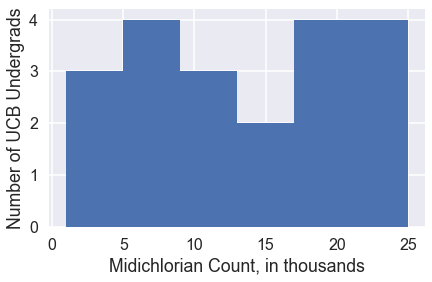

```python
plt.hist(fan_mcounts, 6)
plt.xlabel("Midichlorian Count, in thousands")
plt.ylabel("Number of UCB Undergrads")
```

However, histograms are sensitive to parameter choices, as we can see by simply increasing the number of bins by 2:

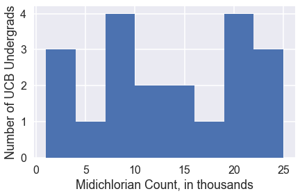

```python
plt.hist(fan_mcounts, 8)
plt.xlabel("Midichlorian Count, in thousands")
plt.ylabel("Number of UCB Undergrads")
```

Other parameters include bin offset (where the bins are centered) and bin openness (whether the left or right endpoints are inclusive). The caveats of histograms are explored in much more detail in this blog post: http://tinlizzie.org/histograms/. How can we improve upon this?

Enter kernel density estimators!

Intuitively, they work very similarly to histograms. We could say that histograms are simple density estimators, while kernel density estimators are like smoothed histograms. While histograms use strict binning, counting how many data points fall into each bin; kernel density estimators sum up the heights of all "kernels" (identical curves) placed at each data point to form a continuous curve. Applying the kernel turns the one data point into a weighted average of several x-values before and after the current datapoint to help determine the y-value of the current datapoint--this is what we call smoothing.

The following image shows how a Kernel Density Estimator

1. applies a kernel centered at each datapoint
2. sums up the heights of the kernel to form the final KDE curve

The x-axis is the value of the midichlorian counts, and the y value is the frequency. The area should add up to 1 (each person certainly has *some* midichlorian count)!

[figure not shown]

In the illustration above, we used a Gaussian (normal) function as the kernel function. The kernel determines the *shape* of the curve, allowing the curve to be more or less smooth.

However, KDEs also have a smoothing parameter called the bandwidth that determines how far left and right to consider x-values, and how to weigh the different x-values.

The bandwidth of the kernel function is the only free parameter for kernel density estimators, so though we still have to pay attention to how our bandwidth selection affects our estimation, we have fewer parameters to worry about than with histograms.

In the end, KDEs are an alternative method to represent the distribution of data that we traditionally use histograms for, with fewer hyperparameters to worry about. KDEs are also good for estimating the distribution of the data, as you actually end up with a one-to-one function.

For example, from the curve above, we can conclude that the midichlorian counts of UC Berkeley students is pretty spread out, with large amounts of students with 7-9, 11-13, and 19-22 thousand midichlorian counts. We can also actually take the curve above and use it to generate a new force-sensitive army of UC Berkeley students with midichlorian counts assigned based on this reasonable estimation of the midichlorian distribution.